# 통계밥법론2 Chap3 실습코드

202140191 엄태훈

2021-09-18(SAT)

# Chap3 Fitting and Graphing Discrete Distributions

이산형 데이터는 종종 다양한 이론적인 포아송,음이항,기하 등의 **확률분포**를 따른다.  
우리가 데이터를 가지고 분석하는데에 있어 데이터가 어떠한 확률분포를 따르는지를 알아내고 가정하는 것은 매우 중요하다. 확률분포를 따르지 않으면 기본적인 통계가정을 만족하지 않으므로 분석을 진행함에 있어 상당한 어려움이 따를 수 있다. 따라서, 데이터에 대한 확률분포를 가정하고 이해하는 것 또한 분석에 있어 중요한 요소 중 하나라고 할 수 있다.

**시각화**는 모델의 진단, 적합도 확인, 추정된 모수에 대한 관측치를 살펴보는데에 사용된다.

**이산형 빈도 분포**는 사고 사망자, 어떤 특성을 가진 혈액 세포와 같은 사건의 발생 횟수를 포함한다.

Chapter3에서는 이항 분포, 포아송 분포, 음이항 분포, 기하분포 등 특정 확률 분포를 살펴보며, 주어진 분포의 데이터를 적합시키는 방법과 그에 대한 시각화, 모델 진단 같은 방법론에 대해서도 알아본다.

## 3.1 Introduction to discrete distributions

이산형 데이터 분석은 하나 이상의 사건 유형에 대한 표 작성 연구와 관련이 있으며, 동전 던지기, 성별, 수술 후 환자의 생존 등과 같은 결과 범주를 예시로 생각할 수 있다.

더 많은 사건에는 더 많은 범주가 나올 수 있으며, 순서를 지정할수도 있다.

Chapter3에서 우리는 숫자 변수로 이루어진 one-way 빈도표에 집중한다.

### 3.1.1 Binomial data

**이항(Binomial)** 데이터는 “성공” 사건의 수에 대한 이산 분포로 발생되며, 각각은 일정한 성공 확률 p로 구성된다.  
일반적으로 **총 시행횟수 n, 성공 확률 p**라는 2개의 모수를 가지고 있으며, 베르누이 분포의 일반화 분포로 이해할 수 있다.

EX)

- 동전 던지기
- 불량품 선별

*Example 3.1: Arbuthnot data*

```r
data("Arbuthnot", package = "HistData")
head(Arbuthnot,5)
```

```
##   Year Males Females Plague Mortality    Ratio Total
## 1 1629  5218    4683      0      8771 1.114243 9.901
## 2 1630  4858    4457   1317     10554 1.089971 9.315
## 3 1631  4422    4102    274      8562 1.078011 8.524
## 4 1632  4994    4590      8      9535 1.088017 9.584
## 5 1633  5158    4839      0      8393 1.065923 9.997
```

`Arbuthnot`데이터는 1629년부터 1710년까지 남성과 여성의 생존비율을 나타낸 데이터로, `HistData`패키지에 포함된 데이터이다.

- Year: 출생년도 (Discrete variable)
- Males: 남성 수 (Discrete variable)
- Females: 여성 수 (Discrete variable)
- plague: 역병으로인한 사망자 수 (Discrete variable)
- Morality: 총 사망자 수 (Discrete variable)
- Ratio: 남성/여성의 비율 (Continuous variable)
- Total: 런던에서의 총 세례식 횟수 (Continuous variable)

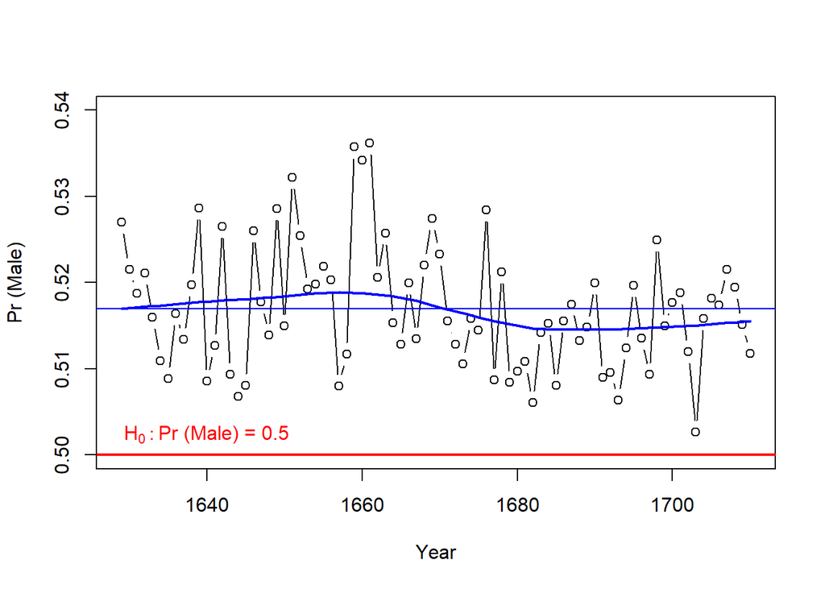

```r
with(Arbuthnot, {
  prob = Males / (Males + Females)
  plot(x = Year, y = prob, type = "b",
       ylim = c(0.5, 0.54), ylab = "Pr (Male)")
  abline(h = 0.5, col = "red", lwd = 2)
  abline(h = mean(prob), col = "blue")
  lines(loess.smooth(Year, prob), col = "blue", lwd = 2)
  text(x = 1640, y = 0.5, expression(H[0]: "Pr (Male) = 0.5"),
       pos = 3, col = "red")
})
```

`Arbuthnot` 데이터를 이용하여 출생년도에 따른 남성의 출생비율을 시각화해보았다.

`with`함수는 데이터에 대해서 여러가지의 작업들을 한 번의 코드 안에서 진행하고 깔끔한 코드 정리를 하고싶을 때 사용한다.  
- `with(data,task)`

- data: 함수를 적용할 데이터
- task: 데이터를 이용하여 진행할 작업들(여러 개의 작업을 진행할 수 있다.)

H0: 남성의 출생 비율은 0.5이다. H1: 남성의 출생 비율은 0.5가 아니다.

*Example 3.2: Families in Saxony*

```r
data("Saxony", package = "vcd")
```

`Saxony`데이터는 Saxony주의 남자 아이들의 숫자에 대한 데이터로 `vcd`패키지안에 포함되어 있다.

- nMales: 남성 아이들의 수 (Factor variable - 0 ~ 12)

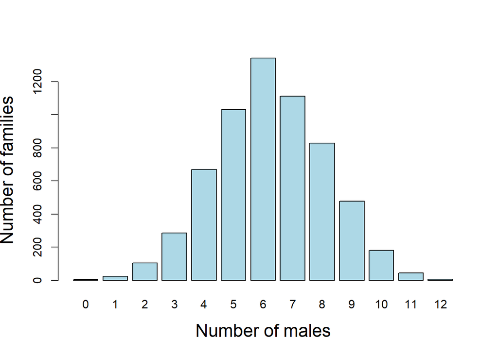

```r
barplot(Saxony, xlab = "Number of males",
        ylab = "Number of families", col = "lightblue",
        cex.lab = 1.5)
```

Saxony데이터의 one-way 빈도표를 한 눈에 살펴보기 위해 **barplot**으로 시각화를 진행해 보았다.  
남자 아이들의 숫자가 6명일 빈도가 가장 많고 그 다음으로는 5명,7명인 것을 확인할 수 있다.  
또한, 데이터의 분포 형태가 **종모양(bell shape)**을 가지는 것을 확인할 수 있다.

*Example 3.3: Weldon’s dice*

```r
data("WeldonDice", package = "vcd")
```

`weldonDice`데이터는 12개의 주사위를 던졌을 때, 5 또는 6이 나왔을 빈도에 대한 데이터로, `vcd`패키지안에 포함 돼 있다.

- n56: 주사위가 5 또는 6이 나온 수 (Factor variable - 0 ~ 10)

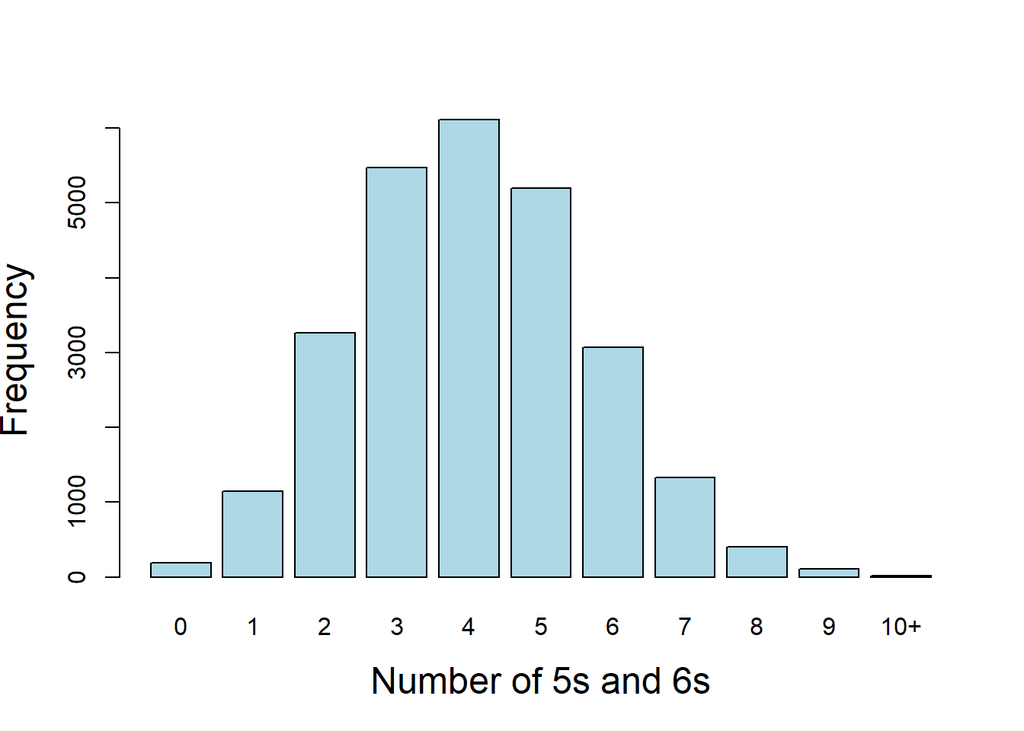

```r
dimnames(WeldonDice)$n56[11] <- "10+"
barplot(WeldonDice, xlab = "Number of 5s and 6s",
        ylab = "Frequency", col ="lightblue", cex.lab = 1.5)
```

`WeldonDice`데이터에서 11번,12번의 빈도가 0므로 10의 수준을 10+로 바꾸어 10,11,12의 경우가 포함되도록 한다.

WeldonDice 데이터의 one-way 빈도표를 **barplot**으로 나타낸 결과, 4번일 빈도가 가장 많고 그 다음으로 3번,5번인 것을 확인할 수 있다.  
WeldonDice 데이터 또한 어느 정도 **종모양(bell shape)**의 형태를 띄는 것을 확인할 수 있었다.

### 3.1.2 Poisson data

**포아송 데이터(Poisson data)**는 고정된 시간 또는 공간 사이에서 사건 k의 수를 관찰하고 이러한 빈도를 표현하는데 사용된다.  
특히, 포아송 분포는 평균과 분산이 같기 때문에 **과대산포**가 발생할 수 있으므로, 포아송 분포 사용시 과대산포를 반드시 유의해야 한다.

EX)

- k시간 동안 콜센터로 걸려오는 전화의 건수
- 책 1페이지당 오탈자가 발생하는 건수
- k주 동안 고속도로에서 교통사고가 발생하는 건수

*Example 3.4: Death by horse kick*

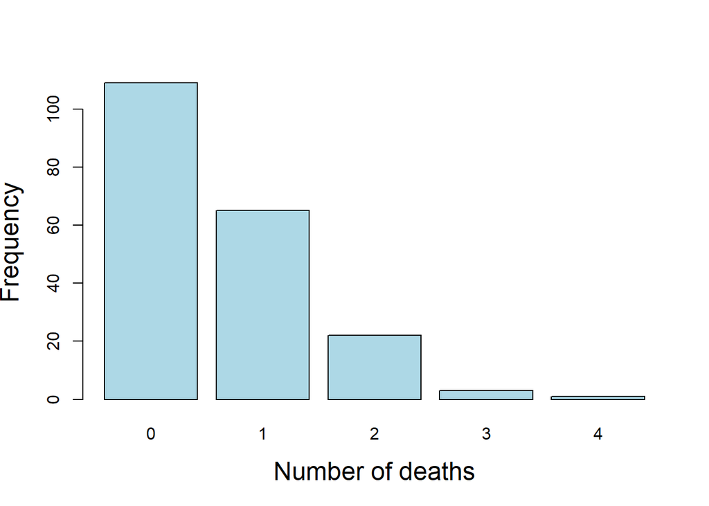

```r
data("HorseKicks", package = "vcd")
barplot(HorseKicks, xlab = "Number of deaths",
        ylab = "Frequency", col = "lightblue",
        cex.lab = 1.5)
```

**HorseKicks**데이터를 **barplot**을 통해 시각화를 진행한 결과 분포는 위와 같다.  
말에게 1명도 사망하지 않는 경우의 빈도가 제일 많고 그 다음으로 1명,2명,3명,4명 순서대로 빈도가 작아지는 것을 확인할 수 있다.

*Example3.5 : Federalist Papers*

```r
data("Federalist", package = "vcd")
```

`Federalist`데이터는 ‘연방주의자 논문’의 저자를 식별하기 위해 특정 키워드(여기서는 ’may’)의 사용을 조사하기 위한 데이터로 `vcd`패키지 안에 포함돼 있다.

- nMay: `may`라는 키워드의 발생 횟수 (Factor variable - 0 ~ 6)

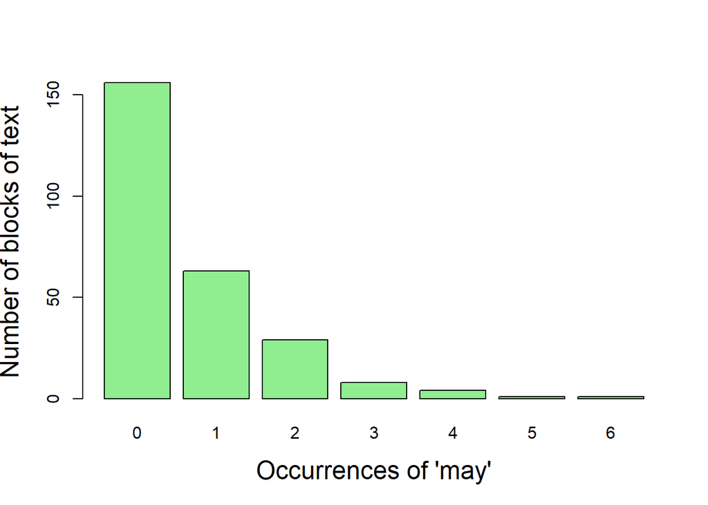

```r
barplot(Federalist,
        xlab = "Occurrences of 'may'",
        ylab = "Number of blocks of text",
        col = "lightgreen", cex.lab = 1.5)
```

**Federalist**데이터를 **barplot**을 통해 시각화를 진행한 결과 분포는 위와 같다.  
`may`라는 키워드를 한 번도 사용하지 않은 경우가 가장 많았고 그 다음으로 1번,2번,3번,4번의 순서대로 빈도가 작아지는 것을 확인할 수 있다.

*Example 3.6: London cycling deaths*

```r
data("CyclingDeaths", package = "vcdExtra")
```

`CyclingDeaths`은 2005년부터 2012년까지 런던 사이클링 선수들의 사망빈도를 나타낸 시계열 데이터로 `vcdExtra`패키지 안에 포함돼 있다.

- date: 연도 (time)
- deaths: 사망자 수 (Discrete Variable)

```r
CyclingDeaths.tab <- table(CyclingDeaths$deaths)
CyclingDeaths.tab
```

```
##
##   0   1   2   3
## 114  75  14   5
```

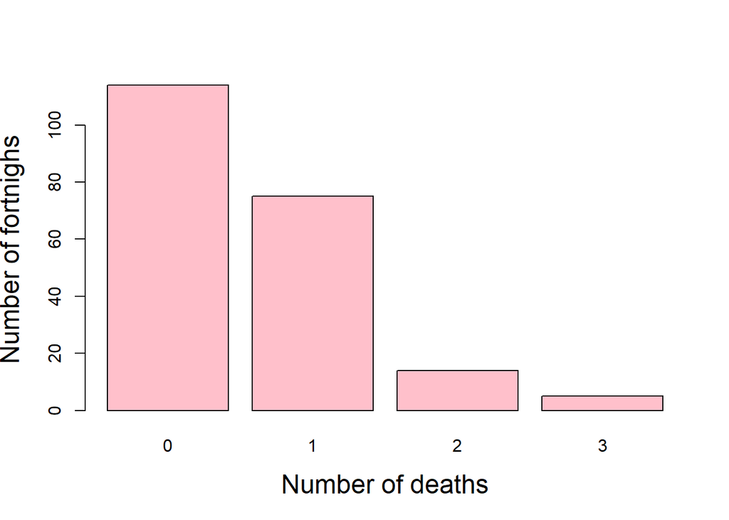

```r
barplot(CyclingDeaths.tab,
        xlab = "Number of deaths", ylab = "Number of fortnighs", col = "pink", cex.lab = 1.5)
```

`table`함수를 통해 one-way 표로 정리한 후, **barplot**을 통해 사망자 수의 분포를 살펴보았다.  
앞선 `Horsekicks, Federalist`의 결과와 거의 유사한 형태이며, 사망자 수가 없을 빈도가 가장 많고 1명,2명,3명 순서대로 빈도가 작아지는 것을 확인할 수 있다.

### 3.1.3 Type-token distributions

*Example 3.7: Butterfly species in Malaya*

```r
data("Butterfly", package = "vcd")
```

`Butterfly`는 501개의 나비 종에 대한 각각의 토큰을 나타낸 데이터로, `vcd`패키지 안에 포함돼 있다.

- nTokens: 나비종의 토큰 수 (Factor variable - 1 ~ 24)

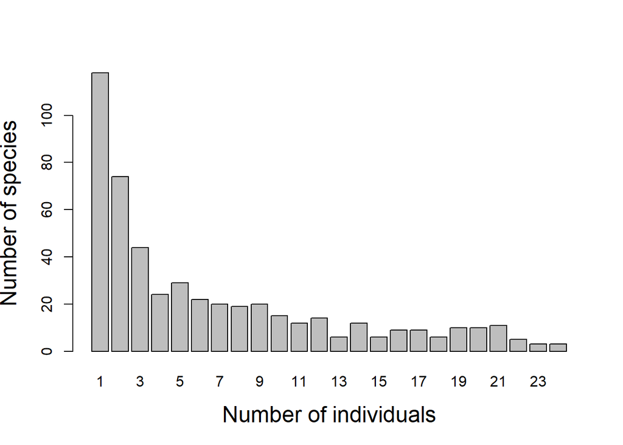

```r
barplot(Butterfly, xlab = "Number of individuals",
        ylab = "Number of species", cex.lab = 1.5)
```

`Butterfly`데이터의 분포를 살펴보기 위해 **barplot**을 활용하여 시각화를 진행한 결과, 토큰의 수가 커질수록 빈도가 점점 작아지는 것을 확인할 수 있다.

## 3.2 Characteristics of discrete distributions

### 3.2.1 The binomial distribution

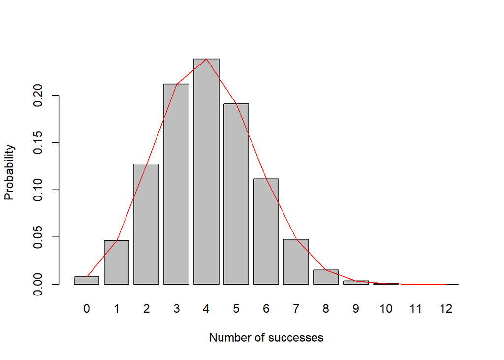

```r
k <- 0:12
pk <- dbinom(k, 12, 1/3)
b <- barplot(pk, names.arg = k,
             xlab = "Number of successes",
             ylab = "Probability")
lines(x = b, y = pk, col ="red")
```

R에서 이항분포의 총 시행횟수, 성공확률을 알 때, 발생확률을 계산하고 싶다면 `dbinom`함수를 통해 간단하게 계산할 수 있다.  
- `dbinom(x,size,prob)`

- x: 성공횟수
- size: 시행횟수
- prob: 성공확률

#### 3.2.1.1 calculation and visualization

*Example 3.8: Weldon’s dice*

```r
Weldon_df <- as.data.frame(WeldonDice)

k <- 0:12
pk <- dbinom(k, 12, 1/3)
pk <- c(pk[1:10], sum(pk[11:13]))
Exp <- round(26306 * pk, 5)
Diff <- Weldon_df$Freq - Exp
Chisq <- Diff^2 / Exp
data.frame(Weldon_df, Prob = round(pk,5),
           Exp, Diff, Chisq)
```

```
##    n56 Freq    Prob        Exp       Diff     Chisq
## 1    0  185 0.00771  202.74946  -17.74946 1.5538553
## 2    1 1149 0.04624 1216.49676  -67.49676 3.7450265
## 3    2 3265 0.12717 3345.36610  -80.36610 1.9306437
## 4    3 5475 0.21195 5575.61016 -100.61016 1.8154792
## 5    4 6114 0.23845 6272.56143 -158.56143 4.0082074
## 6    5 5194 0.19076 5018.04915  175.95085 6.1694696
## 7    6 3067 0.11127 2927.19533  139.80467 6.6771580
## 8    7 1331 0.04769 1254.51229   76.48771 4.6634615
## 9    8  403 0.01490  392.03509   10.96491 0.3066798
## 10   9  105 0.00331   87.11891   17.88109 3.6700801
## 11 10+   18 0.00054   14.30532    3.69468 0.9542366
```

```r
p <- c(1/6, 1/3, 1/2, 2/3)
k <- 0:12
(Prob <- outer(k, p, function(k,p) dbinom(k,12,p)))
```

```
##               [,1]         [,2]         [,3]         [,4]
##  [1,] 1.121567e-01 7.707347e-03 0.0002441406 1.881676e-06
##  [2,] 2.691760e-01 4.624408e-02 0.0029296875 4.516023e-05
##  [3,] 2.960936e-01 1.271712e-01 0.0161132813 4.967626e-04
##  [4,] 1.973957e-01 2.119520e-01 0.0537109375 3.311751e-03
##  [5,] 8.882807e-02 2.384460e-01 0.1208496094 1.490288e-02
##  [6,] 2.842498e-02 1.907568e-01 0.1933593750 4.768921e-02
##  [7,] 6.632496e-03 1.112748e-01 0.2255859375 1.112748e-01
##  [8,] 1.136999e-03 4.768921e-02 0.1933593750 1.907568e-01
##  [9,] 1.421249e-04 1.490288e-02 0.1208496094 2.384460e-01
## [10,] 1.263333e-05 3.311751e-03 0.0537109375 2.119520e-01
## [11,] 7.579995e-07 4.967626e-04 0.0161132813 1.271712e-01
## [12,] 2.756362e-08 4.516023e-05 0.0029296875 4.624408e-02
## [13,] 4.593937e-10 1.881676e-06 0.0002441406 7.707347e-03
```

```r
str(Prob)
```

```
##  num [1:13, 1:4] 0.1122 0.2692 0.2961 0.1974 0.0888 ...
```

`outer`함수는 계산할 함수와 데이터가 여러개 있을 때, 조금 더 편리하게 계산할 수 있도록 돕는 함수이다.  
- `outer(x,y,fun)`

- x: 계산할 벡터 또는 행렬
- y: 계산할 벡터 또는 행렬
- fun: 계산에 사용할 함수

성공확률 변화에 따른 이항분포의 확률계산 값을 Prob변수에 저장하였다.  
성공확률(p)의 값을 4개로 넣어줬기 때문에 `str`함수를 사용했을 때 13x4형태로 값이 구성되있는 것을 알 수 있다.

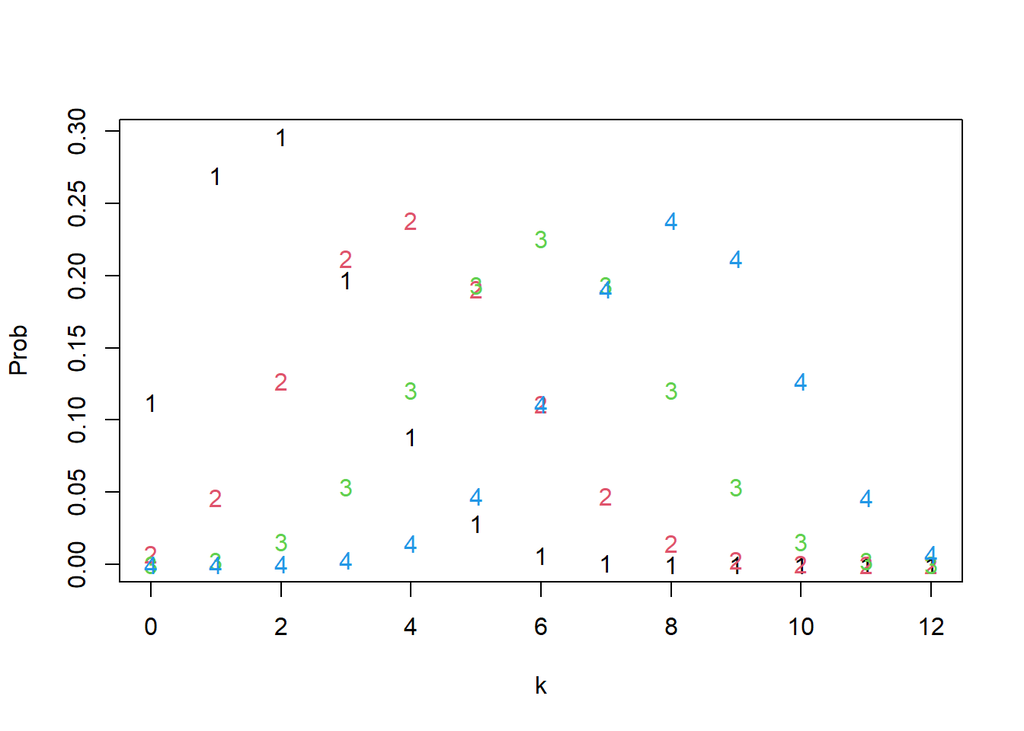

```r
matplot(k, Prob)
```

성공확률의 변화에 따른 이항분포의 변화를 `matplot`을 통해 시각화를 하였다.

`matplot`은 matrix의 열을 그래프 위에 표시하도록 도와주는 함수이다.  
- `matplot(x,y)`

- x: 그래프의 x축에 표시할 데이터
- y: 그래프의 y축에 표시할 데이터

`matplot`에 추가적인 옵션을 지정하지 않으면 위와 같이 해당 값의 열 번호가 출력된다.

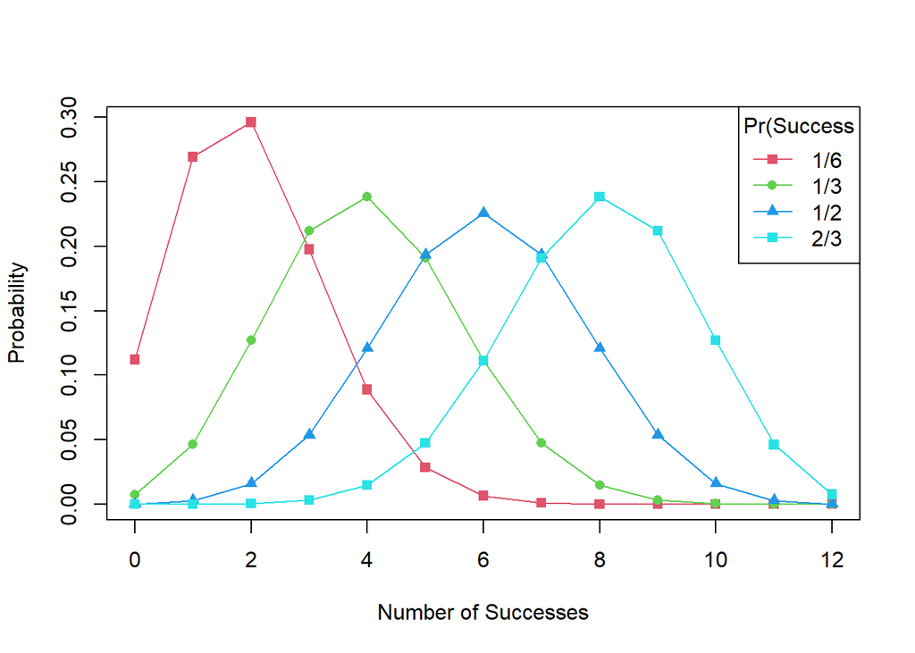

```r
col <- palette()[2:5]
matplot(k, Prob,
        type = "o", pch = 15: 17, col = col, lty = 1,
        xlab = "Number of Successes", ylab = "Probability")
legend("topright", legend = c("1/6","1/3","1/2","2/3"),
       pch = 15:17, lty = 1, col = col,
       title = "Pr(Success")
```

여러가지 옵션을 추가하여 변화의 추이를 조금 더 쉽게 살펴볼 수 있도록 하였다.

성공확률이 커짐에 따라, 가장 큰 확률값을 가지는 성공횟수가 점차 큰쪽으로 변하는 것을 확인할 수 있다.

### 3.2.2 The Poisson distribution

*Example 3.9: UK soccer scores*

```r
data("UKSoccer", package = "vcd")
```

`UKSoccer`데이터는 1995/1996 영국 프로축구 리그의 스코어를 홈과 어웨이에 따라서 구분한 데이터로, `vcd`패키지 안에 포함돼 있다.

- Home: 홈에서의 득점 (Factor variable - 0,1,2,3,4)
- Away: 원정에서의 득점 (Factor variable - 0,1,2,3,4)

```r
soccer.df <- as.data.frame(UKSoccer, stringsAsFactors = FALSE)
soccer.df <- within(soccer.df, {
  Home <- as.numeric(Home)
  Away <- as.numeric(Away)
  Total <- Home + Away
})
str(soccer.df)
```

```
## 'data.frame':    25 obs. of  4 variables:
##  $ Home : num  0 1 2 3 4 0 1 2 3 4 ...
##  $ Away : num  0 0 0 0 0 1 1 1 1 1 ...
##  $ Freq : num  27 59 28 19 7 29 53 32 14 8 ...
##  $ Total: num  0 1 2 3 4 1 2 3 4 5 ...
```

테이블로 구성된 데이터를 데이터 프레임의 형태로 바꾸고 홈득점과 원정득점을 합친 `Total`변수를 추가해 주었다.

```r
library(vcdExtra)
soccer.df <- expand.dft(soccer.df)
head(soccer.df)
```

```
##   Home Away Total
## 1    0    0     0
## 2    0    0     0
## 3    0    0     0
## 4    0    0     0
## 5    0    0     0
## 6    0    0     0
```

`expand.dft`함수를 이용하여 빈도변수를 제외하고 빈도의 수 만큼 변수들의 관측값이 만들어지도록 하였다.

즉, **Home = 2, Away = 0, Total = 2, Freq = 28** 이라면 Freq 변수는 제외하고 데이터의 행에 **Home = 2, Away = 0, Total = 2**라는 관측값이 28개 만들어지도록 하는 것이다.

```r
apply(soccer.df,2, function(x) c(mean =mean(x), var = var(x)))
```

```
##          Home     Away    Total
## mean 1.486842 1.063158 2.550000
## var  1.316449 1.172782 2.617546
```

`apply`함수를 통해 Home, Away에 따른 스코어의 평균, 분산값을 쉽게 구하는것을 확인할 수 있다.

홈의 경우 평균 1.48득점, 원정의 경우 평균 1.06득점이 발생하는 것을 확인할 수 있다.

*Example 3.10: London cycling deaths*

```r
with(CyclingDeaths, c(mean = mean(deaths),
                      var = var(deaths),
                      ratio = mean(deaths) / var(deaths)))
```

```
##      mean       var     ratio
## 0.5673077 0.5268488 1.0767942
```

런던 사이클리스트의 사망자 수가 포아송분포를 따르는지 확인해본다.  
평균 값으로 보아 경주당 평균 0.57명 또는 한 달에 1명 이상 사망한 것을 알 수 있다.

```r
mean.deaths <- mean(CyclingDeaths$deaths)
ppois(5, mean.deaths, lower.tail = FALSE)
```

```
## [1] 2.854305e-05
```

`ppois`함수는 포아송분포의 범위확률을 계산할 수 있도록 도와주는 함수 중 하나이다.  
- `ppois(q,lambda,lower.tail)`

- q: 분석가가 계산하고자 하는 발생횟수 범위의 기준
- labmda: 포아송 분포의 단위시간당 평균 발생 횟수
- lower.tail: 확률 계산 방법 (TRUE = P(X<x), FALSE = P(X>x))

`ppois`를 통해 5명 이상의 사망한 확률을 계산하였다. 계산결과, 확률이 매우 작은 것으로 보아 5명 이상의 사망발생 확률은 매우 작다는 것을 확인할 수 있다.

#### 3.2.2.1 Calculation and visualization

*Example 3.11: Plotting styles for discrete distributions*

```r
KL <- expand.grid(k = 0:20, lambda = c(1,4,10))
pois_df <- data.frame(KL, prob = dpois(KL$k, KL$lambda))
pois_df$lambda <- factor(pois_df$lambda)
str(pois_df)
```

```
## 'data.frame':    63 obs. of  3 variables:
##  $ k     : int  0 1 2 3 4 5 6 7 8 9 ...
##  $ lambda: Factor w/ 3 levels "1","4","10": 1 1 1 1 1 1 1 1 1 1 ...
##  $ prob  : num  0.3679 0.3679 0.1839 0.0613 0.0153 ...
```

```r
head(pois_df)
```

```
##   k lambda        prob
## 1 0      1 0.367879441
## 2 1      1 0.367879441
## 3 2      1 0.183939721
## 4 3      1 0.061313240
## 5 4      1 0.015328310
## 6 5      1 0.003065662
```

`exapnd.grid`함수를 통해 주어진 **k,lambda**에 대한 모든 가능한 조합을 구성하고 그에대한 포아송 확률을 갖고있는 **pois_df**데이터를 생성하였다.

`dpois`는 포아송분포의 특정 발생횟수에 대한 확률을 계산하고자 할때 사용하는 함수이다.  
- `dpois(x,lambda)`

- x: 분석가가 계산하고자하는 발생횟수
- lambda: 포아송 분포의 단위시간당 평균 발생 횟수

```r
library(lattice)
```

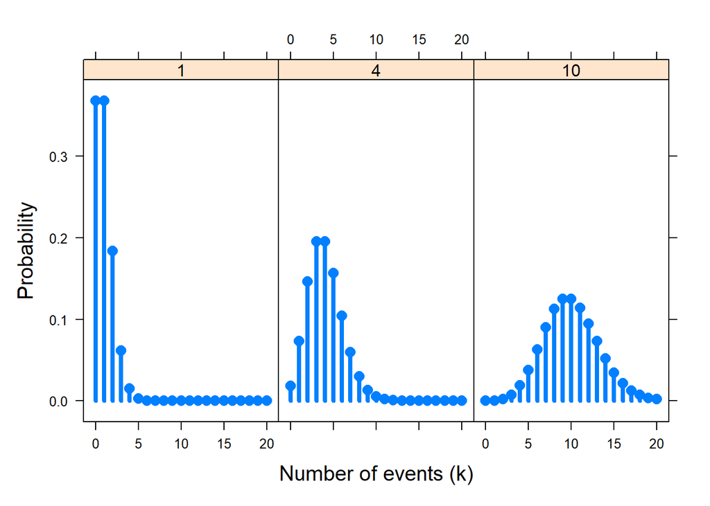

```r
xyplot(prob ~ k | lambda, data = pois_df,
       type = c("h","p"), pch = 16, lwd = 4, cex = 1.25, layout = c(3,1),
       xlab = list("Number of events (k)", cex = 1.25),
       ylab = list("Probability", cex = 1.25))
```

`lattice`패키지는 다변량 데이터의 시각화를 돕기위해 설계되었으며, 특정 데이터에 대해서 그룹을 나눠 시각화를 진행하고자 할때 유용하게 사용할 수 있는 패키지이다.

생성된 데이터 pois_df를 `xyplot`을 이용하여 시각화를 하였다.  
`xyplot`은 plot을 그림에 있어 특정 그룹을 통해 layout을 나눌 수 있게 도와주는 시각화 함수이며, 이를 통해 lambda에 따른 포아송 분포를 더 쉽게 비교 할 수 있다. - `xyplot(formula,data)`

- formula: 그래프에 변수를 표현하는 방법 (y ~ x | group)은 y변수를 y축, x변수를 x축으로하고 group에 따라 layout을 나눠달라는 의미이다.
- data: 시각화에 사용할 데이터

lambda가 커짐에 따라 포아송 분포의 형태가 정규분포와 같은 **종모양(bell-shape)**의 형태를 가지는 것을 확인할 수 있다.

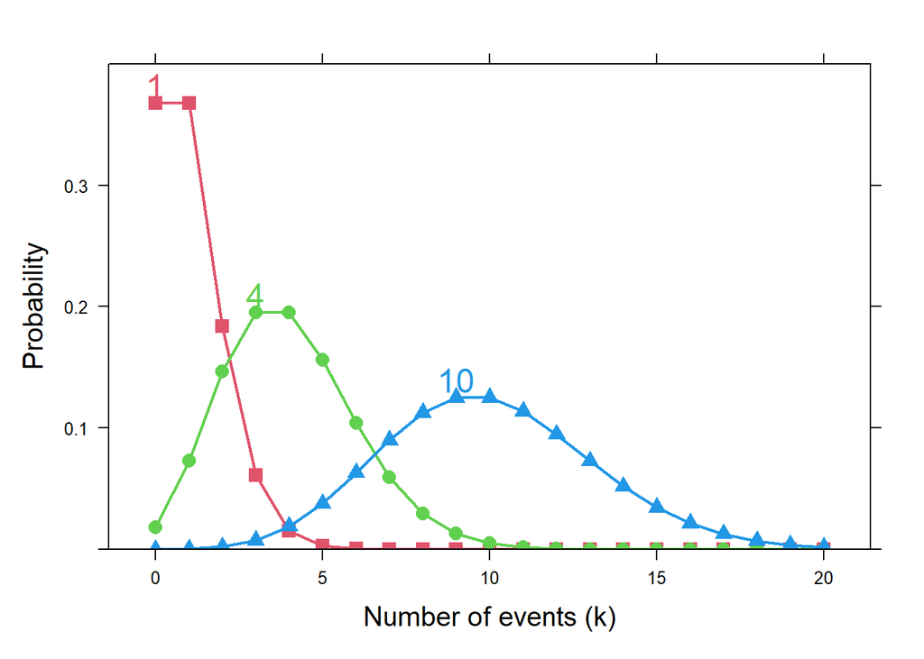

```r
mycol <- palette() [2:4]
plt <- xyplot(prob ~ k, data = pois_df, groups = lambda,
              type = "b", pch = 15 : 17, lwd = 2, cex = 1.25, col = mycol,
              xlab = list("Number of events (k)", cex = 1.25),
              ylab = list("Probability", cex = 1.25),
              ylim = c(0, 0.4))
library(directlabels)
direct.label(plt,list("top.points", cex = 1.5, dl.trans(y = y + 0.1)))
```

`directlabels`패키지는 `lattice, ggplot2`를 활용하여 시각화를 진행하였을 때, 레이블을 직접 그림에 자동적으로 배치할 수 있도록 도와주는 함수들이 구성돼있는 패키지이다.

`direct.label`함수를 이용하여 패널을 나누지 않고 하나의 grid안에 모든 포아송 분포를 겹쳐서 나타낼수도 있다.  
- `direct.label(graph, option)`

- graph: plot이 저장돼있는 객체
- option: 추가적으로 지정할 옵션 (위의 코드의경우, 레이블의 위치, 포인터 크기, 축의 범위를 조정하였다.)

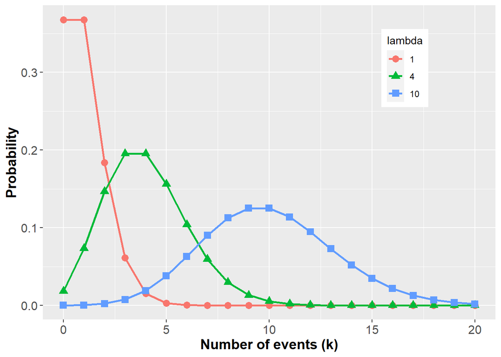

```r
library(ggplot2)
gplt <- ggplot(pois_df,
               aes(x = k, y = prob, colour = lambda, shape = lambda)) +
  geom_line(size = 1) + geom_point(size = 3)+
  xlab("Number of events (k)")+
  ylab("Probability")
gplt + theme(legend.position = c(0.8, 0.8)) +
  theme(axis.text = element_text(size = 12),
        axis.title = element_text(size = 14, face = "bold"))
```

`ggplot2`패키지의 `ggplot`을 이용하여 그리는 방법도 고려해볼 수 있다.

`ggplot2 | ggplot`은 R의 가장 강력한 그래픽 기는 중 하나로, 현대 R을 사용하는 대부분의 데이터 사이언티스트들이 시각화를 위해 사용하는 패키지이다. 시각화를 위한 다양한 함수 및 세부적인 조정을 위한 다양한 옵션을 제공한다.  
- `ggplot(data, aes(x,y,colour)) + option`

- data: 시각화에 쓰일 데이터
- aes: 축 설정
- x: x축에 쓰일 데이터
- y: y축에 쓰일 데이터
- colour: 그래프에서의 그룹지정
- option: 추가적인 옵션(+를 이용하여 세부적인 옵션을 여러개 추가 가능)

### 3.2.3 The negative binomial distribution

**음이항 분포(Negative binomial distribution)**은 대기 시간 분포의 한 유형이지만 포아송 분포의 일반화로서 과대산포(분산 > 평균)가 가능하다.  
**음이항 분포**는 어떤 사건의 일정한 확률 p로 관찰되며, 성공적인 사건을 관찰하는데 얼마나 많은 실패가 필요한지 궁금할 때 사용된다.

EX)

- 동전을 10번 던질 때, 5번째 시행에서 3번째 앞면이 나올 확률 (성공확률 = p)
- 100개의 불량품 검사를 할 때, 50번째 시행에서 5번째 불량품이 나올 확률 (불량품이 나올 확률 = p)

#### 3.2.3.1 Calculation and visualization

```r
k <- 2
n <- 2:4
p <- 0.2
dbinom(k,n,p)
```

```
## [1] 0.0400 0.0960 0.1536
```

```r
(mu <- n * (1-p) / p)
```

```
## [1]  8 12 16
```

```r
dnbinom(k,n,mu = mu)
```

```
## [1] 0.07680 0.03072 0.01024
```

```r
dnbinom(k,n,p)
```

```
## [1] 0.07680 0.03072 0.01024
```

`dnbinom`함수는 음이항분포의 확률값을 계산하는데 사용된다.  
- `dnbinom(k,n,p,mu)`

- k: 실패횟수
- n: 성공횟수
- p: 성공확률
- mu: 음이항분포의 평균

`dnbinom`을 사용할때, 음이항분포의 평균을 사용해서 계산하거나 성공확률을 사용해서 계산하거나 같은 확률값이 출력되는 것을 확인할 수 있다.

```r
XN <- expand.grid(k = 0:20, n = c(2,4,6), p = c(0.2,0.3,0.4))
nbin_df <- data.frame(XN, prob = dnbinom(XN$k, XN$n, XN$p))
nbin_df$n <- factor(nbin_df$n)
nbin_df$p <- factor(nbin_df$p)
str(nbin_df)
```

```
## 'data.frame':    189 obs. of  4 variables:
##  $ k   : int  0 1 2 3 4 5 6 7 8 9 ...
##  $ n   : Factor w/ 3 levels "2","4","6": 1 1 1 1 1 1 1 1 1 1 ...
##  $ p   : Factor w/ 3 levels "0.2","0.3","0.4": 1 1 1 1 1 1 1 1 1 1 ...
##  $ prob: num  0.04 0.064 0.0768 0.0819 0.0819 ...
```

```r
head(nbin_df,5)
```

```
##   k n   p    prob
## 1 0 2 0.2 0.04000
## 2 1 2 0.2 0.06400
## 3 2 2 0.2 0.07680
## 4 3 2 0.2 0.08192
## 5 4 2 0.2 0.08192
```

만들어진 k,n,p에 대하여 `expand.grid`를 통해 모든 가능한 조합을 생성하고 각각의 확률값을 구한 후, 데이터 프레임 형태로 **nbin_df**객체에 저장하였다.

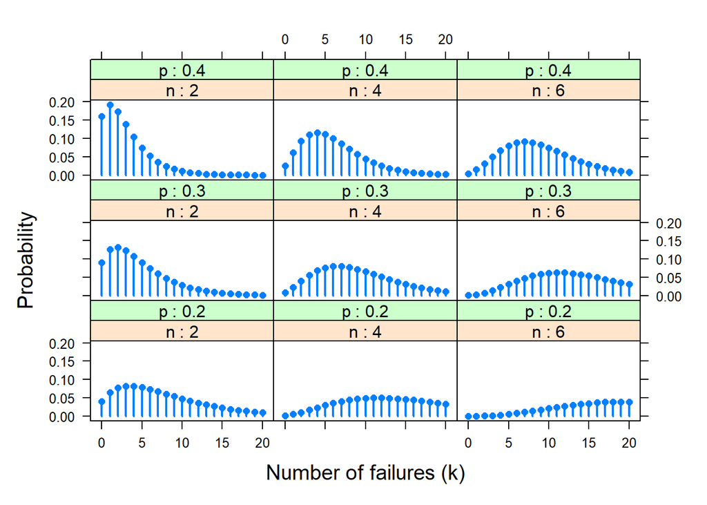

```r
xyplot(prob ~ k | n + p, data = nbin_df,
       xlab = list("Number of failures (k)", cex = 1.25),
       ylab = list("Probability", cex = 1.25),
       type = c("h", "p"), pch = 16, lwd = 2,
       strip = strip.custom(strip.names = TRUE))
```

k,n,p 변화에 따른 음이항 분포의 변화를 `xyplot`을 통해 시각화 하였다.  
n과 p가 작은경우, 확률값의 분포는 크게 차이가 없어보이고 n과 p가 커질수록 음이항분포의 분포가 정규분포의 **종모양(bell-shape)**와 비슷해지는 것을 확인할 수 있다.

```r
n <- c(2,4,6)
p <- c(0.2,0.3,0.4)
NP <- outer(n,p, function(n, p) n * (1-p) / p)
dimnames(NP) <- list(n = n, p = p)
NP
```

```
##    p
## n   0.2       0.3 0.4
##   2   8  4.666667   3
##   4  16  9.333333   6
##   6  24 14.000000   9
```

각각의 조합에 대한 음이항 분포의 평균을 table로 나타내었다.

### 3.2.4 The geometric distribution

**기하분포(geometric distribution)**의 경우, 음이항 분포의 특수한 형태로, 첫번째로 성공할 사건 이전까지의 실패의 사건을 살펴본다.

EX)

- 동전을 던질때, 3번째 시행에서 앞면이 나올 확률
- 주사위를 던질때, 6번째 시행에서 5가 나올 확률

## 3.3 Fitting discrete distributions

*Example 3.12: Death by horsekick*

```r
tab <- as.data.frame(HorseKicks, stringsAsFactors = FALSE)
colnames(tab) <- c("nDeaths", "Freq")
str(tab)
```

```
## 'data.frame':    5 obs. of  2 variables:
##  $ nDeaths: chr  "0" "1" "2" "3" ...
##  $ Freq   : int  109 65 22 3 1
```

```r
(lambda <- weighted.mean(as.numeric(tab$nDeaths), w = tab$Freq))
```

```
## [1] 0.61
```

`HorseKicks`데이터를 통해 모수가 $\lambda$ = 평균 사망자 수를 갖는 포아송 분포를 예상한다.

`weighted.mean`은 빈도를 가중치로 하는 가중평균을 계산할 수 있게 도와주는 함수이다.  
- `weihted.mean(data,w)`

- data: 가중평균을 계산할 데이터
- w: 가중평균을 계산할 때 사용할 가중치

빈도를 가중치로 하여, 가중평균을 계산한 결과, (예상한) 평균 사망자 수 $\lambda$ = 0.61이 계산된다.

```r
phat <- dpois(0 : 4, lambda = lambda)
exp <- sum(tab$Freq) * phat
chisq <- (tab$Freq - exp)^2 / exp

GOF <- data.frame(tab, phat, exp, chisq)
GOF
```

```
##   nDeaths Freq        phat         exp      chisq
## 1       0  109 0.543350869 108.6701738 0.00100106
## 2       1   65 0.331444030  66.2888060 0.02505734
## 3       2   22 0.101090429  20.2180858 0.15704840
## 4       3    3 0.020555054   4.1110108 0.30025340
## 5       4    1 0.003134646   0.6269291 0.22200573
```

계산된 $\lambda$를 통해 우리는 데이터의 예상 사망자 수를 계산할수 있다.  
실제 관측된 사망자수와 예측된 사망자 수는 큰 차이가 없는 것처럼 보인다.

```r
(sum(chisq))
```

```
## [1] 0.7053659
```

```r
(pchisq(sum(chisq), df = nrow(tab) - 2, lower.tail = FALSE))
```

```
## [1] 0.8719411
```

적합도 검정의 귀무가설과 대립가설은 다음과 같다.

- H0: 주어진 데이터가 (우리가 가정한)분포를 따른다.
- H1: 주어진 데이터가 (우리가 가정한)분포를 따르지 않는다.

### 3.3.1 R tools for discrete distributions

*Example 3.13: Families in Saxony*

```r
library(vcd)
data("Saxony", package = "vcd")
Sax_fit <- goodfit(Saxony, type = "binomial")
unlist(Sax_fit$par)
```

```
##      prob      size
##  0.519215 12.000000
```

R에서는 `goodfit`함수를 통해 분포에 대한 적합도 검정을 간단하게 진행할 수 있다.  
- `goodfit(data, type )`

- data: 적합도 검정을 진행할 데이터
- type: 가정하는 분포(“binomial”, “poisson” 등)

`unlist`는 list로 구성된 데이터에 대해서 list의 형태를 지우고 싶을때 사용하는 함수이다.  
- `unlist(data)`

- data: list의 형태를 지우고 싶은 데이터

`Saxony`데이터를 이항분포로 가정했을 때, 주어진 데이터의 성공확률 (가족들 중 남성이 있을 확률)은 0.519로 추정된다.

```r
names(Sax_fit)
```

```
## [1] "observed" "count"    "fitted"   "type"     "method"   "df"       "par"
```

```r
Sax_fit
```

```
##
## Observed and fitted values for binomial distribution
## with parameters estimated by `ML'
##
##  count observed       fitted pearson residual
##      0        3    0.9328394        2.1402809
##      1       24   12.0888374        3.4257991
##      2      104   71.8031709        3.7996298
##      3      286  258.4751335        1.7120476
##      4      670  628.0550119        1.6737139
##      5     1033 1085.2107008       -1.5849023
##      6     1343 1367.2793552       -0.6566116
##      7     1112 1265.6303069       -4.3184059
##      8      829  854.2466464       -0.8637977
##      9      478  410.0125627        3.3576088
##     10      181  132.8357027        4.1789562
##     11       45   26.0824586        3.7041659
##     12        7    2.3472734        3.0368664
```

`goodfit`결과를 저장한 객체는 관측빈도의 수준(level), 관측값, 가정분포로 계산했을 때의 관측값, 관측값과 가정분포를 통해 계산한 관측값의 피어슨 잔차 등의 속성을 포함하고 있는 것을 확인할 수 있다.

```r
summary(Sax_fit)
```

```
##
##   Goodness-of-fit test for binomial distribution
##
##                      X^2 df     P(> X^2)
## Likelihood Ratio 97.0065 11 6.978187e-16
```

summary를 통해 지정한 분포에 대한 적합도 결과를 쉽게 살펴볼 수 있다. 적합도 검정은 ML방법에 의해 계산된 것을 확인할 수 있다.  
유의확률 p는 유의수준 0.05보다 작으므로 귀무가설을 기각한다.  
따라서, 주어진 데이터는 **이항분포를 따르지 않는 데이터**라고 할 수 있다.

*Example 3.14: Weldon’s dice*

```r
data("WeldonDice", package = "vcd")
dice_fit <- goodfit(WeldonDice, type = "binomial",
                    par = list(size = 12))
unlist(dice_fit$par)
```

```
##      prob      size
##  0.337686 12.000000
```

`WeldonDice`데이터를 이항분포로 가정했을 때, 추정된 phat(5 또는 6이 나올 확률) = 0.3377임을 확인할 수 있다.

```r
print(dice_fit, digits = 0)
```

```
##
## Observed and fitted values for binomial distribution
## with parameters estimated by `ML'
##
##  count observed fitted pearson residual
##      0      185    187               -0
##      1     1149   1147                0
##      2     3265   3216                1
##      3     5475   5465                0
##      4     6114   6269               -2
##      5     5194   5114                1
##      6     3067   3042                0
##      7     1331   1330                0
##      8      403    424               -1
##      9      105     96                1
##     10       18     15                1
##     11        0      1               -1
##     12        0      0               -0
```

```r
summary(dice_fit)
```

```
##
##   Goodness-of-fit test for binomial distribution
##
##                       X^2 df  P(> X^2)
## Likelihood Ratio 11.50623  9 0.2425973
```

적합도 검정 결과, 유의확률 p는 유의수준 0.05보다 크므로 귀무가설을 기각할 수 없다.  
따라서, 주어진 데이터에 대해서 **이항분포를 따른다고 가정하는 것은 적합함**을 알 수 있다.

*Example 3.15: Death by horsekick*

```r
data("HorseKicks", package = "vcd")
HK_fit <- goodfit(HorseKicks, type = "poisson")
HK_fit$par
```

```
## $lambda
## [1] 0.61
```

`HorseKicks`데이터를 포아송 분포로 가정했을 때, 추정된 $\lambda$값(평균 사망 횟수)은 0.61임을 알 수 있다.

```r
HK_fit
```

```
##
## Observed and fitted values for poisson distribution
## with parameters estimated by `ML'
##
##  count observed      fitted pearson residual
##      0      109 108.6701738       0.03163952
##      1       65  66.2888060      -0.15829510
##      2       22  20.2180858       0.39629333
##      3        3   4.1110108      -0.54795383
##      4        1   0.6269291       0.34142169
```

```r
summary(HK_fit)
```

```
##
##   Goodness-of-fit test for poisson distribution
##
##                        X^2 df  P(> X^2)
## Likelihood Ratio 0.8682214  3 0.8330891
```

적합도 검정 결과, 유의확률 p는 유의수준 0.05보다 크므로 귀무가설을 기각할 수 없다.  
따라서, 주어진 데이터에 대해서 **포아송 분포를 따른다고 가정하는 것은 적합함**을 알 수 있다.

*Example 3.16: Federalist Papers*

```r
data("Federalist", package = "vcd")
Fed_fit0 <- goodfit(Federalist, type = "poisson")
unlist(Fed_fit0$par)
```

```
##    lambda
## 0.6564885
```

`Federalist`데이터를 포아송 분포로 가정했을 때, 추정된 $\lambda$값(may의 평균 발생 횟수)은 0.6564885이다.

```r
Fed_fit0
```

```
##
## Observed and fitted values for poisson distribution
## with parameters estimated by `ML'
##
##  count observed       fitted pearson residual
##      0      156 135.89138870       1.72498813
##      1       63  89.21114067      -2.77508554
##      2       29  29.28304617      -0.05230572
##      3        8   6.40799484       0.62890261
##      4        4   1.05169381       2.87493431
##      5        1   0.13808499       2.31948309
##      6        1   0.01510854       7.62061255
```

```r
summary(Fed_fit0)
```

```
##
##   Goodness-of-fit test for poisson distribution
##
##                       X^2 df     P(> X^2)
## Likelihood Ratio 25.24312  5 0.0001250511
```

적합도 검정 결과, 유의확률 p는 유의수준 0.05보다 작으므로 귀무가설을 기각한다.  
따라서, 주어진 데이터에 대해서 **포아송 분포를 따른다고 가정하는 것은 적합하지 않음**을 알 수 있다.

```r
Fed_fit1 <- goodfit(Federalist, type = "nbinomial")
unlist(Fed_fit1$par)
```

```
##      size      prob
## 1.1863297 0.6437582
```

```r
summary(Fed_fit1)
```

```
##
##   Goodness-of-fit test for nbinomial distribution
##
##                       X^2 df  P(> X^2)
## Likelihood Ratio 1.964028  4 0.7423751
```

`Federalist`데이터를 음이항 분포로 가정한 후, 적합도 검정을 다시 진행해 보았다.

유의확률 p는 유의수준 0.05보다 크므로 귀무가설을 기각하지 못한다.  
따라서, 주어진 데이터에 대해서 **음이항 분포를 따른다고 가정하는 것은 적합함**을 알 수 있다.

### 3.3.2 Plots of observed and fitted frequencies

관측빈도와 적합빈도의 그림은 적합된 이론적 분포의 형태와 데이터와 이론 사이의 편차의 패턴을 모두 보여주는데 도움이 된다.

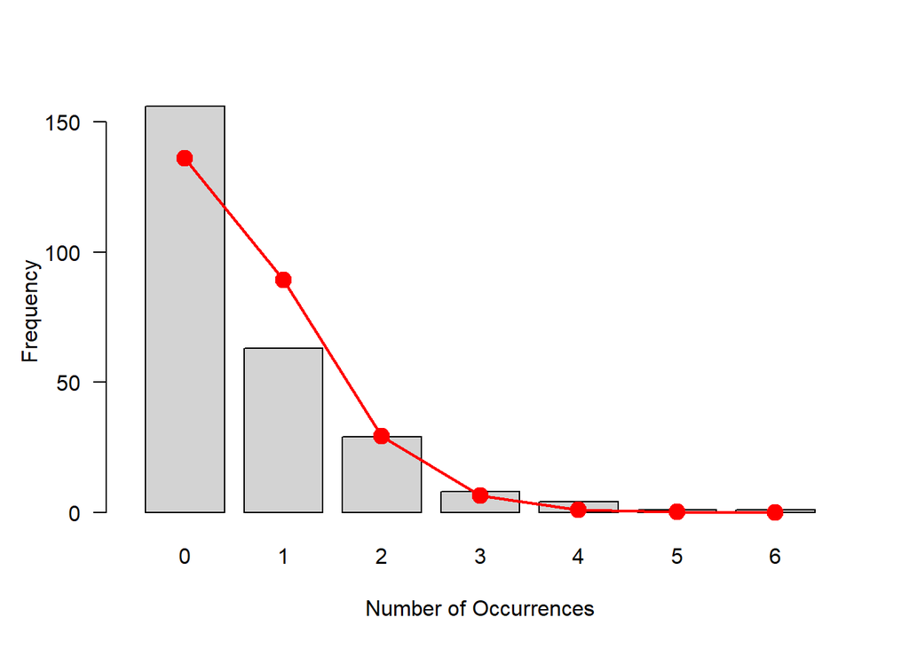

```r
plot(Fed_fit0, scale = "raw", type = "standing")
```

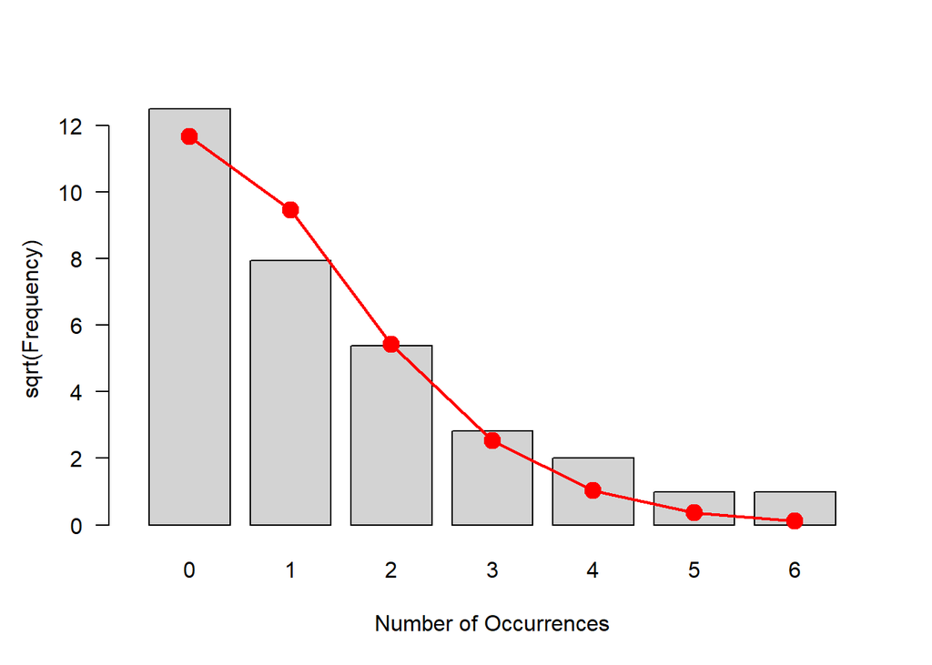

```r
plot(Fed_fit0, type = "standing")
```

첫번째 그래프의 경우, 실제 데이터에 대한 분포이며, 두번쨰 그래프의 경우 더 작은 빈도를 더 잘보이게 하기위해 Tukey가 제안한 **rootogram** 그래프이다.  
두번째 그래프의 경우, y축은 기존 빈도에 **root**를 씌운 값임을 확인할 수 있다.

회색으로 그려진 막대는 실제 데이터의 관측값, 빨간색으로 표시된 점은 특정 분포를 가정했을 때의 관측값(기대값)임을 확인할 수 있다.

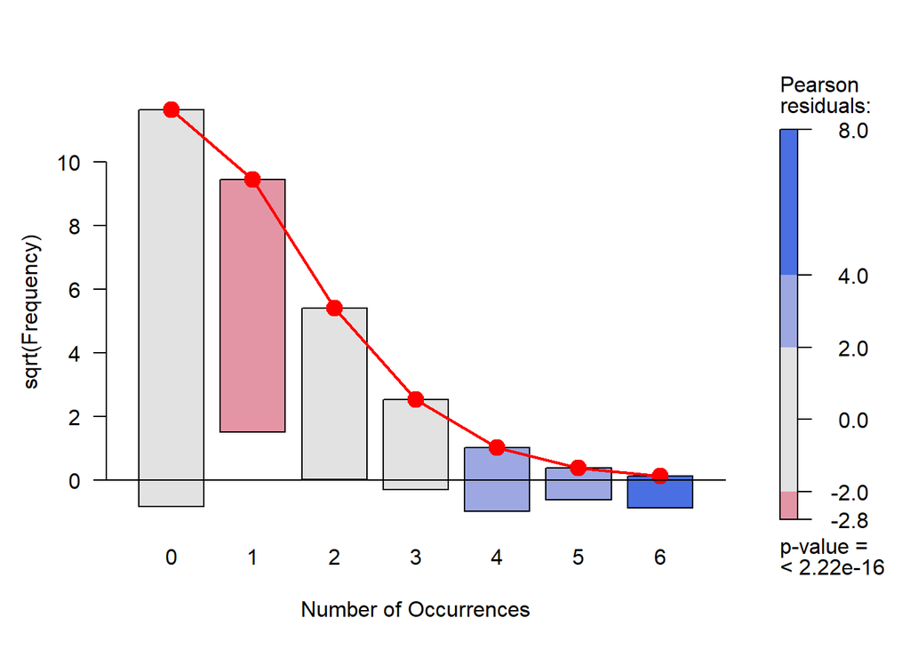

```r
plot(Fed_fit0, type = "hanging", shade = TRUE)
```

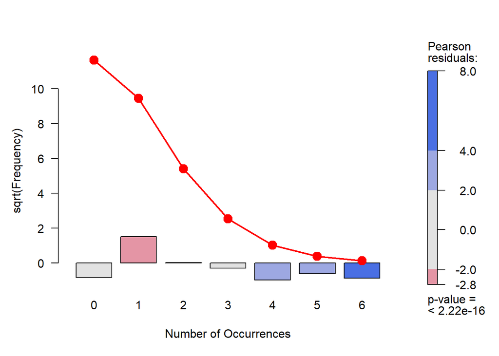

```r
plot(Fed_fit0, type = "deviation", shade = TRUE)
```

두 그래프 모두 루토그램을 사용한 그래프이다.  
첫번째 그래프의 경우, 막대를 이동하여 위쪽이 예상 빈도에 맞도록 한다. 두번째 그래프의 경우, 관측 빈도와 적합 빈도간의 차이를 강조한다.  
또한, 두 그래프 모두 `shade = TRUE`옵션을 추가하여 피어슨 잔차에 대한 정보 및 적합도 검정같은 추가적인 정보를 얻을 수 있게 하였다.

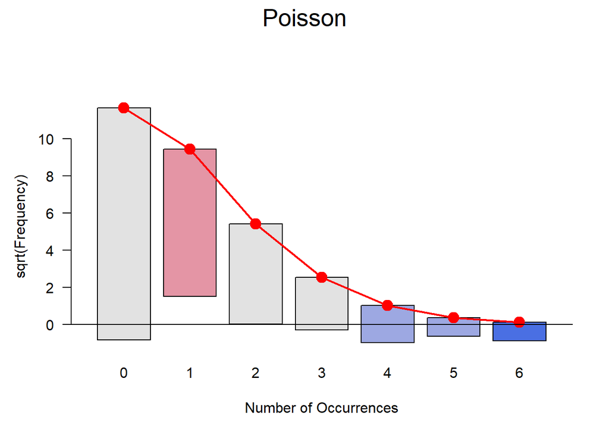

```r
plot(Fed_fit0, main = "Poisson", shade = TRUE, legend = FALSE)
```

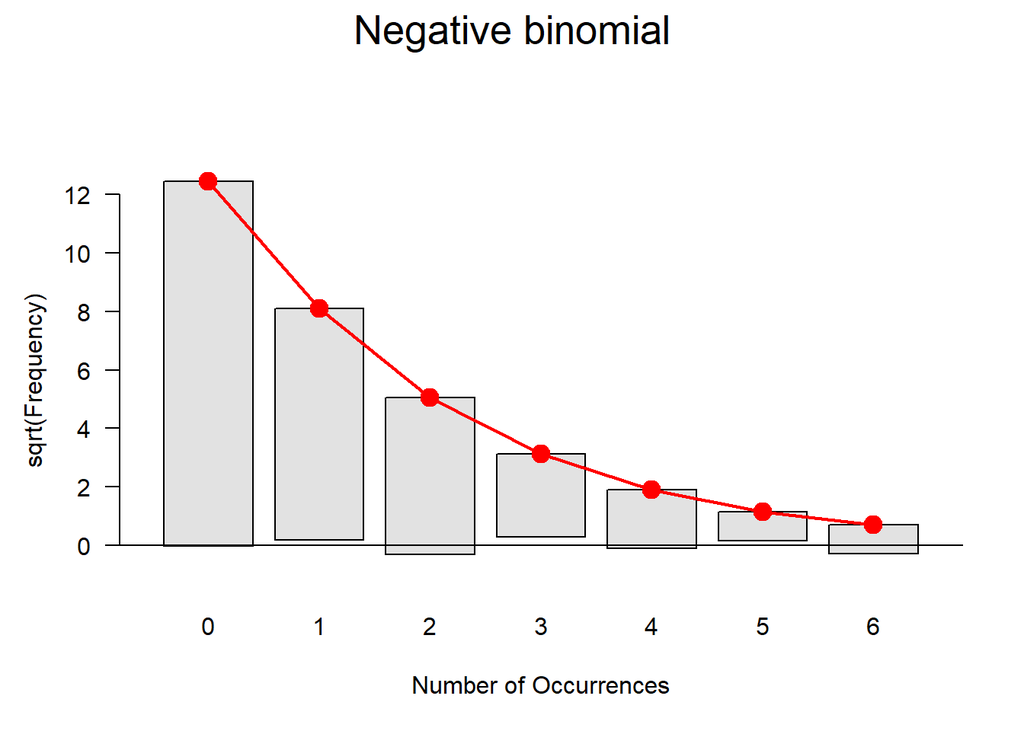

```r
plot(Fed_fit1, main = "Negative binomial", shade = TRUE, legend = FALSE)
```

첫번째 그래프의 경우, 데이터에 적합하지 않은 `포아송분포`를 가정하여 사용했으므로, 관측 빈도와 적합 빈도 사이의 이탈이 많다.  
이에 반해, `음이항분포`를 가정한 두번쨰 그래프는 이탈된 부분이 없는것을 볼 수 있다. 따라서, 주어진 `Federalist`데이터는 **음이항분포로 가정하는 것이 적합함**을 그래프를 통해서도 쉽게 살펴볼 수 있다.

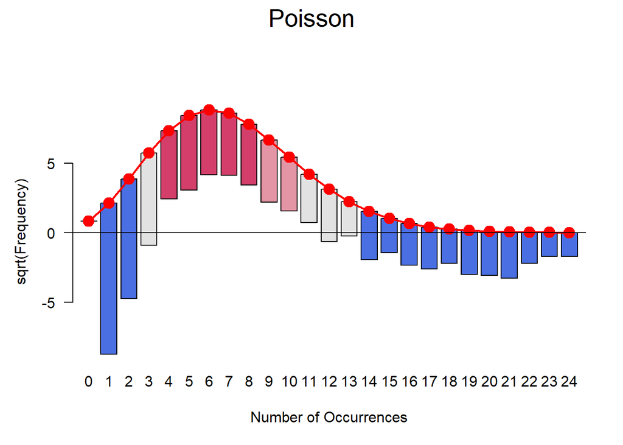

```r
data("Butterfly", package = "vcd")
But_fit1 <- goodfit(Butterfly, type = "poisson")
But_fit2 <- goodfit(Butterfly, type = "nbinomial")
plot(But_fit1, main = "Poisson", shade = TRUE, legend = FALSE)
```

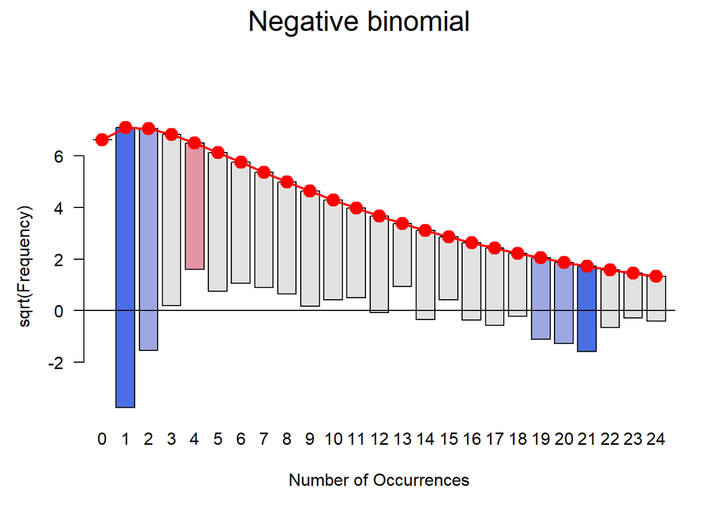

```r
plot(But_fit2, main = "Negative binomial", shade = TRUE, legend = FALSE)
```

첫번째 포아송 가정의 그래프의 경우, 과대, 과소 평가하는 부분이 대부분인 것을 볼 수 있고 두번째 그래프 또한 어느정도 존재하는 것을 알 수 있다.

```r
summary(But_fit1)
```

```
##
##   Goodness-of-fit test for poisson distribution
##
##                       X^2 df P(> X^2)
## Likelihood Ratio 1656.023 22        0
```

```r
summary(But_fit2)
```

```
##
##   Goodness-of-fit test for nbinomial distribution
##
##                       X^2 df     P(> X^2)
## Likelihood Ratio 239.4982 21 5.229179e-39
```

또한, 적합도 검정의 유의확률 모두 유의수준 0.05보다 작은 것을 확인할 수 있다.  
이를통해, `Butterfly` 데이터는 **포아송, 음이항 모두 적절한 분포 가정이 아닌것**을 확인할 수 있다.

## 3.4 Diagnosing discrete distributions: Ord plots

이상적으로 이산 분포를 위해 선택된 일반적인 형식은 데이터 생성을 위한 그럴듯한 메커니즘의 실직적인 지식에 의해 지시되어야 한다.  
그러나 이러한 지식이 부족한 경우, 특정 데이터셋의 적합한 분포를 알기 쉽지 않다.

이러한 경우, 한 가지 간단한 대안으로 **Ord**를 고려해볼 수 있다.

`Ord plot`은 `vcd`패키지에 포함된 함수로, 데이터가 이산형 분포 중 어떠한 분포를 따르는지에 대한 진단을 해주고 분포를 가정한 뒤, 가정한 분포를 통해 얻어진 추정직선을 제시한다.  
- `Ord_plot(data)`

- data: Ord를 통해 분포를 진단할 데이터

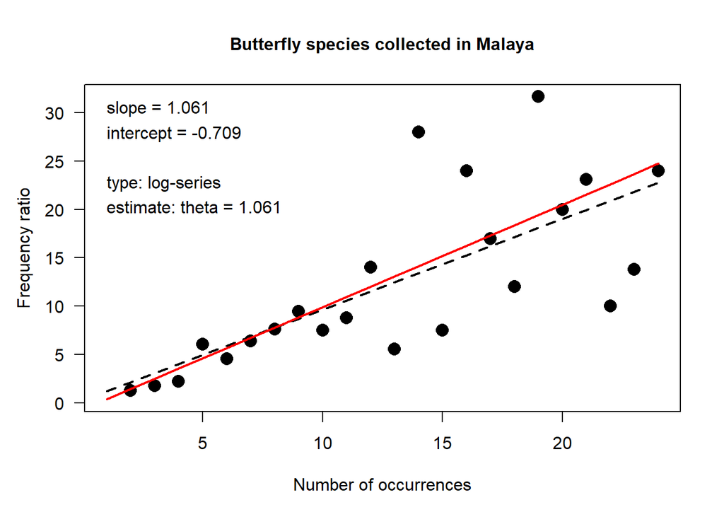

```
##  Intercept      Slope
## -0.7089609  1.0608209
```

```r
(ord <- Ord_plot(Butterfly,
                main = "Butterfly species collected in Malaya",
                gp = gpar(cex = 1), pch = 16))
```

```r
ord
```

```
##  Intercept      Slope
## -0.7089609  1.0608209
```

검은색 석은 발생횟수 빈도에 대한 일반적인 최소 제곱 회귀적합을 나타내며, 빨간색 선은 가중치를 적용한 최소 제곱 적합을 나타낸다.

위의 그래프의 경우, 두 선의 절편과 기울기는 상당히 가까운 것처럼 보인다.  
`Ord_plot`을 통해 `Butterfly`데이터에 대한 이산 분포 진단 결과, $\theta$ = 1.061의 값을 가지는 로그 시리즈 분포로 진단한 것을 알 수 있다.

#### 3.4.0.1 Ord plot examples

*Example 3.17: Death by horse kick*

```r
data("HorseKicks", pacakge = "vcd")
nk <- as.vector(HorseKicks)
k <- as.numeric(names(HorseKicks))
nk1 <- c(NA, nk[-length(nk)])
y <- k * nk / nk1
weight <- sqrt(pmax(nk, 1) - 1)
(ord_df <- data.frame(k, nk, nk1, y, weight))
```

```
##   k  nk nk1         y    weight
## 1 0 109  NA        NA 10.392305
## 2 1  65 109 0.5963303  8.000000
## 3 2  22  65 0.6769231  4.582576
## 4 3   3  22 0.4090909  1.414214
## 5 4   1   3 1.3333333  0.000000
```

`Ord_plot`진단을 위한 필요한 값들을 생성하고 객체 Ord_df에 넣어준다.

```r
coef(lm(y ~ k, weights = weight, data = ord_df))
```

```
## (Intercept)           k
##  0.65601572 -0.03414076
```

가중치를 적용한 최소 제곱 회귀선의 결과를 통한 회귀 계수는 위와 같으며, 이 경우 식은 **y = -0.034k + 0.656** 이다.

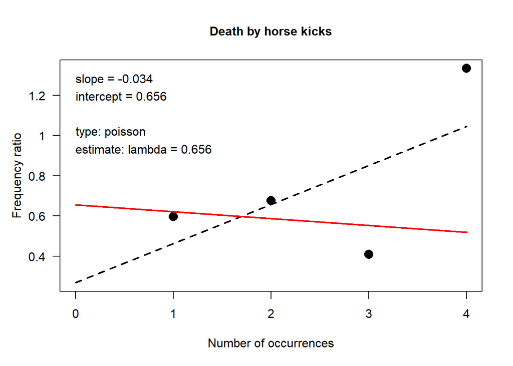

```r
Ord_plot(HorseKicks,
         main = "Death by horse kicks",
         gp = gpar(cex = 1),
         pch = 16)
```

`HorseKicks`데이터의 `Ord_plot`을 통한 이산 분포 진단결과, $\lambda$ = 0.656을 가지는 포아송 분포로 진단한 것을 확인할 수 있다.

*Example 3.18: Federalist Papers*

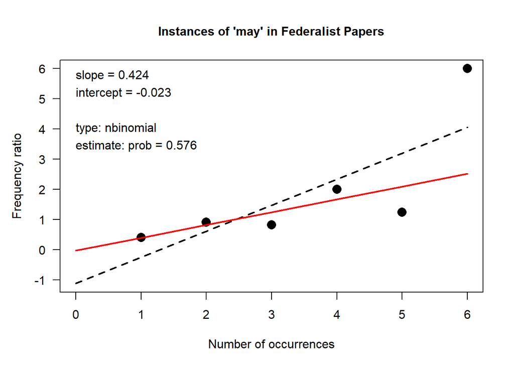

```r
Ord_plot(Federalist, main = "Instances of 'may' in Federalist Papers",
         gp = gpar(cex = 1),
         pch = 16)
```

`Federalist`데이터의 `Ord_plot`을 통한 이산 분포 진단결과, $p$ = 0.576을 가지는 음이항 분포로 진단한 것을 확인할 수 있다.

*Example 3.19: Women in queues*

```r
data("WomenQueue", package = "vcd")
WomenQueue
```

```
## nWomen
##  0  1  2  3  4  5  6  7  8  9 10
##  1  3  4 23 25 19 18  5  1  1  0
```

`WomenQueue`데이터는 `vcd`패키지에 포함된 데이터로, 런던 지하철역의 100개의 대기열 중, 길이가 10인 대기열에서의 여성의 대기 숫자를 나타낸다.

- nWomen: 여성의 수(Factor Variable - 1 ~ 10)

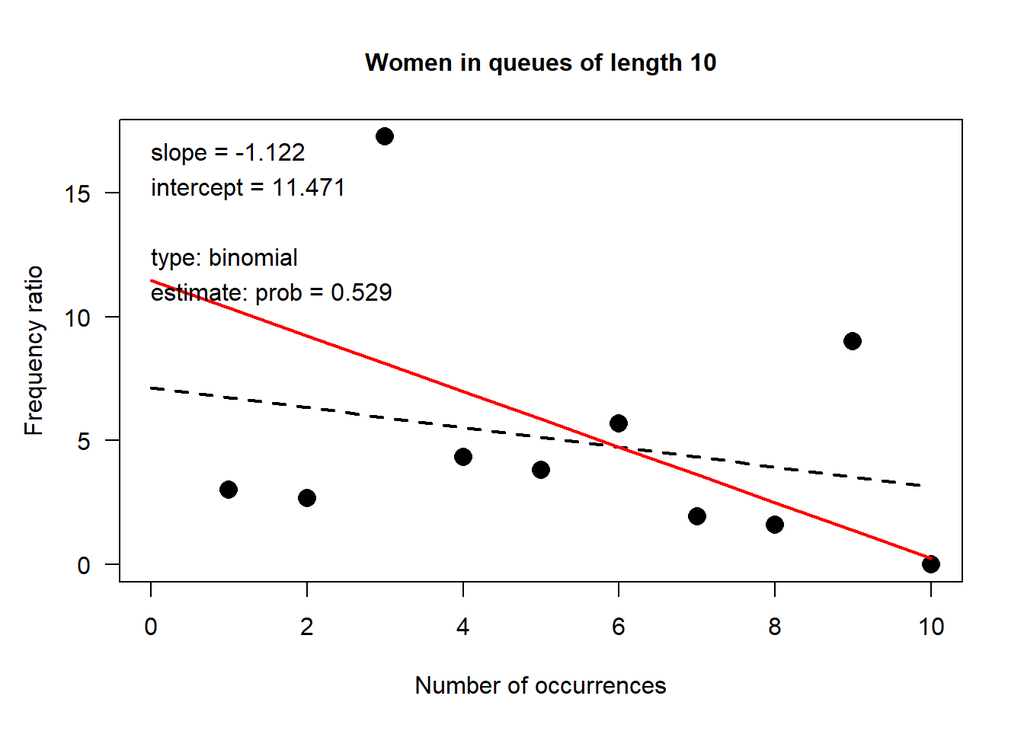

```r
Ord_plot(WomenQueue, main = "Women in queues of length 10",
         gp = gpar(cex = 1), pch = 16)
```

`WomenQueue`데이터의 `Ord_plot`을 통한 이산 분포 진단결과, $p$ = 0.529을 가지는 이항 분포로 진단한 것을 확인할 수 있다.

## 3.5 Poissonness plots and generalized distribution plots

포아송 분포는 one-way표가 포아송 분포를 얼마나 잘따르는지 볼 수 있는 **robust plot**이다.  
데이터가 포아송에서 벗어날 때, 점들은 곡선이 된다.

### 3.5.3 The distplot() function

포아송 그림은 `vcd`패키지의 `distplot`을 통해 그릴 수 있다(`type = poisson`적용).  
`distplot`은 포아송 그림 뿐만 아니라 다른 분포에 대해서도 `Ord_plot`과 비슷하게 이산분포에 대한 진단을 해주고 적합된 점에 대한 신뢰구간을 제공한다.  
- `distplot(data,type)`

- data: distplot 함수를 적용할 데이터
- type: 분석가가 진단하고자 하는 이산 분포(“poisson”, “binomial”, “nbinomial”등)

*Example 3.20: Death by horse kick*

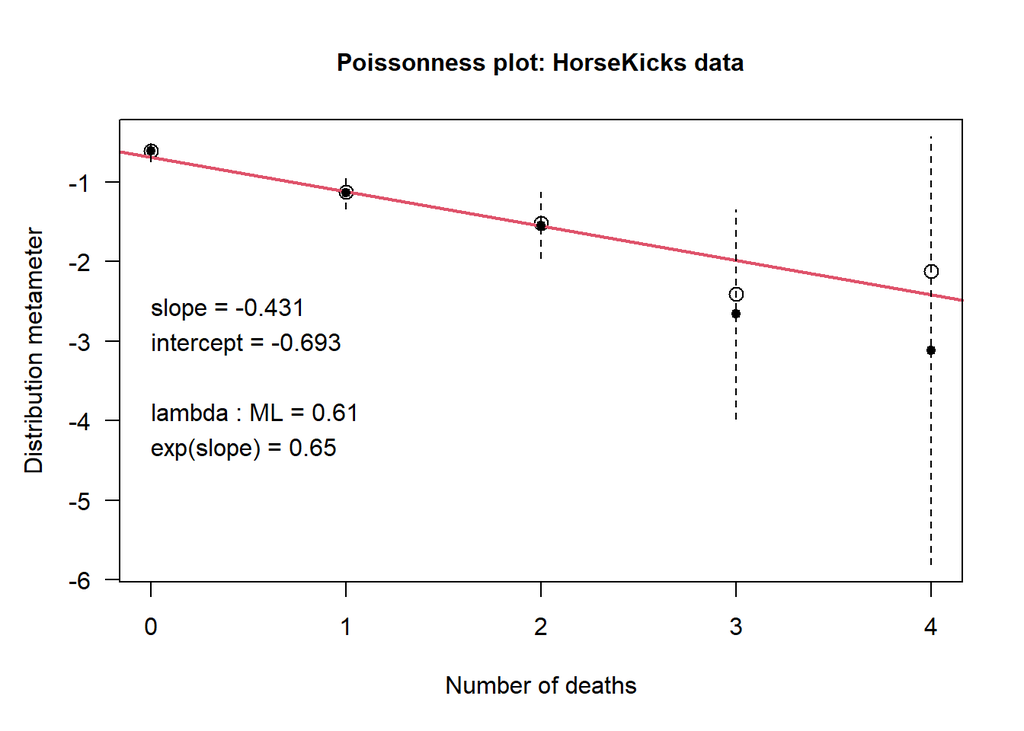

```r
data("HorseKicks", package = "vcd")
dp <- distplot(HorseKicks, type = "poisson",
               xlab = "Number of deaths",
               main = "Poissonness plot: HorseKicks data")
```

그래프에서 **열린 원**은 계산된 관측값을 보여준다.  
검은색으로 채워져있는 **작은 점**은 신뢰구간의 중심을 나타내며, **점선**은 신뢰구간의 범위를 나타낸다.  
**포아송 분포를** 가정할 때, 추정되는 모수 $\lambda$ = 0.61인 것을 확인할 수 있다.

```r
print(dp, digits = 4)
```

```
##   Counts Freq Metameter CI.center CI.width CI.lower CI.upper
## 1      0  109    -0.607   -0.6131   0.1305  -0.7436  -0.4827
## 2      1   65    -1.124   -1.1343   0.2069  -1.3412  -0.9274
## 3      2   22    -1.514   -1.5451   0.4169  -1.9620  -1.1281
## 4      3    3    -2.408   -2.6607   1.3176  -3.9783  -1.3431
## 5      4    1    -2.120   -3.1203   2.6887  -5.8089  -0.4316
```

`displot`을 저장한 객체의 정보를 살펴보면, 추정값, 신뢰구간의 중심 값, 신뢰밴드의 너비, 신뢰구간의 하한과 신뢰구간의 상한 값을 알 수 있다.

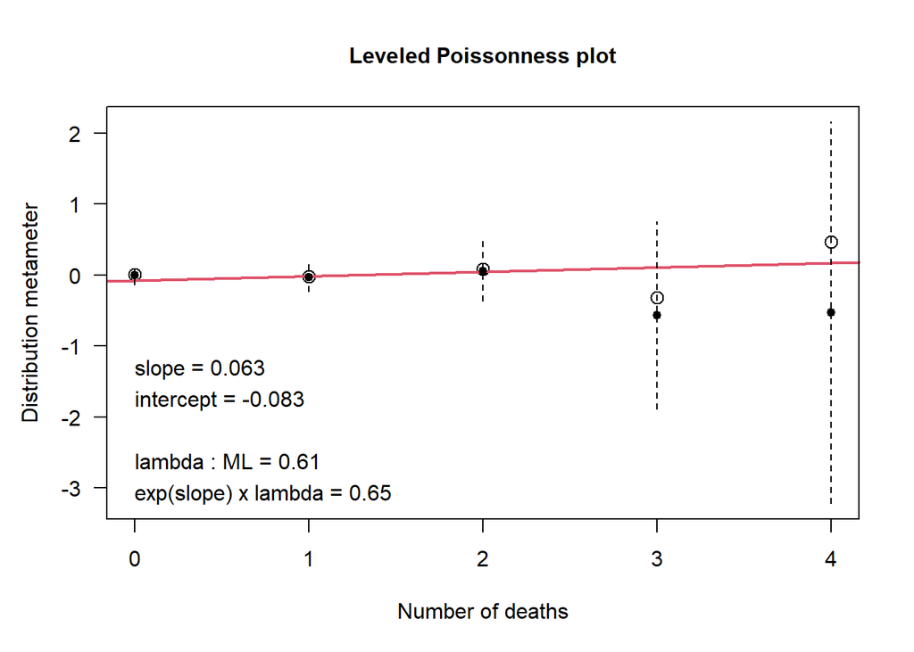

```r
distplot(HorseKicks, type = "poisson", lambda = 0.61,
         xlab = "Number of deaths",
         main = "Leveled Poissonness plot")
```

앞서 `distplot`을 통해 추정된 $\lambda$ = 0.61을 적용하고 다시 한 번 포아송 그림을 그린 결과는 위와 같다.  
첫 번째 그림과 달리, 기울기가 양수로 바뀌고 추정선이 약간 완만해진 것을 확인할 수 있다.

두 그림 모두 적합된 선이 신뢰구간 내에 있는 것으로 보아, **포아송 분포로 가정한 후 데이터를 적합하는 것은 올바른 분포 가정**임을 알 수 있다.

### 3.5.4 Plots for other distributions

*Example 3.21: Families in Saxony*

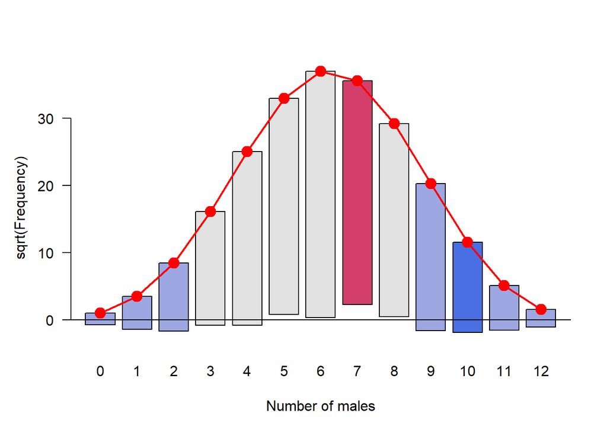

```r
plot(goodfit(Saxony, type = "binomial", par = list (size = 12)),
     shade = TRUE, legend = FALSE,
     xlab = "Number of males")
```

`Saxony`데이터에 **이항분포**를 가정한 후, **goodfit plot**을 그린 결과, 과대,과소 추정된 부분이 보이는 것을 확인할 수 있으며, 이를 통해 `Saxony`데이터는 **이항분포로 가정하는 것이 적합하지 않은 것**임을 알 수 있다.

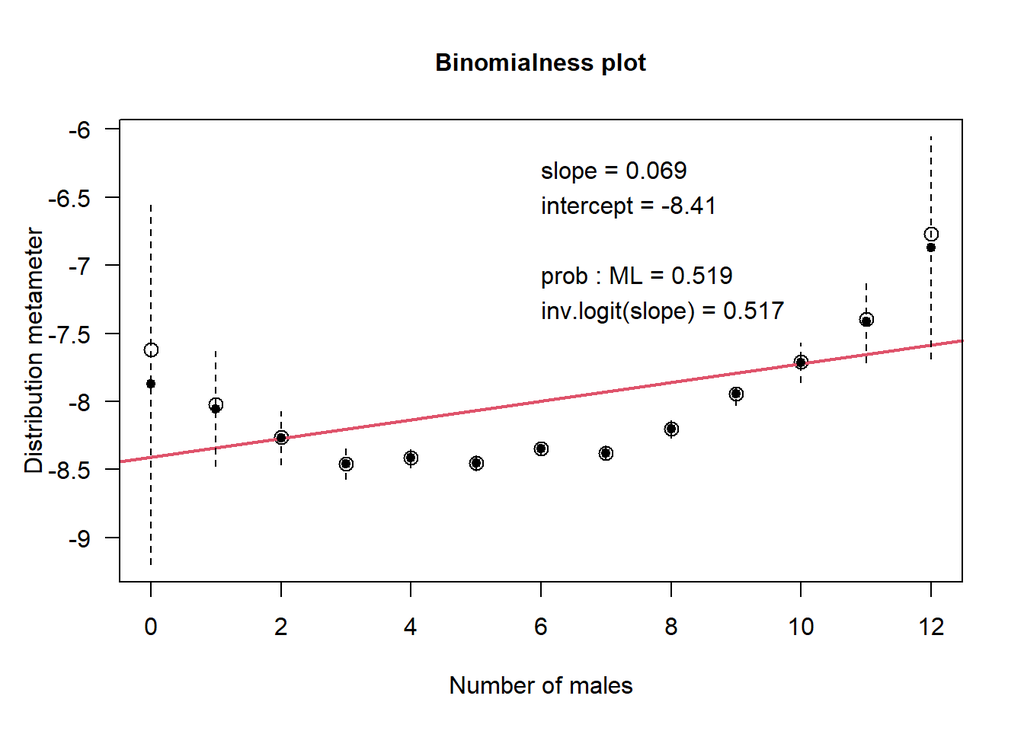

```r
distplot(Saxony, type = "binomial", size = 12,
        xlab = "Number of males")
```

`displot`을 사용하여 **이항분포**를 가정한 후, 이산분포를 진단해 보았다.  
추정된 $p$ = 0.519이지만, 적합된 선이 대부분의 점에서 신뢰구간을 벗어나는 것을 확인할 수 있다.  
따라서, `Saxony`데이터가 **이항분포로 가정하기에 적절하지 않음**을 다시 한 번 살펴볼 수 있다.

*Example 3.22: Federalist Papers*

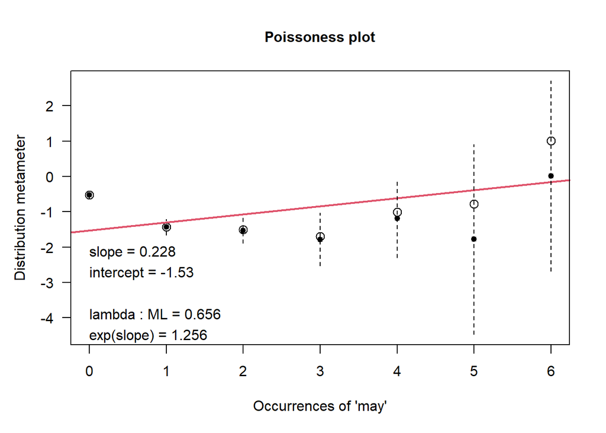

```r
distplot(Federalist, type = "poisson", xlab = "Occurrences of 'may'")
```

`Federalist`데이터를 **포아송 분포**로 가정하고, `displot`을 통해 이산분포 진단을 해본 결과, 추정된 모수 값 $\lambda$ = 0.656이다.  
하지만, 적합된 선이 몇몇의 점에서 신뢰구간을 벗어나는 것을 확인할 수 있다.  
따라서, `Federalist`데이터를 **포아송 분포로 가정하는 것은 적절하지 않은 것**을 알 수 있다.

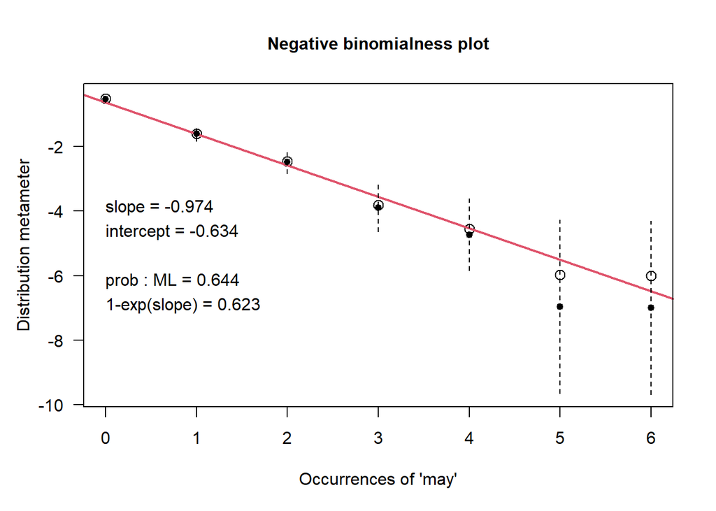

```r
distplot(Federalist, type = "nbinomial", xlab = "Occurrences of 'may'")
```

`Federalist`데이터를 **음이항 분포**로 가정하고, `distplot`을 통해 이산분포 진단을 해본 결과, 추정된 모수 $p$ = 0.644이며, 적합된 선이 하나의 점에서 약간의 신뢰구간을 벗어나지만 나머지 점들은 모두 신뢰구간 안에 속하는 것을 살펴볼 수 있다.  
따라서, `Federalist`데이터는 포아송 분포가 아닌 **음이항 분포로 가정하는 것이 적합한 것**임을 알 수 있다.